# Statistica (Dl-Pas)

Università Ca’ Foscari di Venezia, Corso di Laurea triennale in Economia e Commercio.

## Esame

L’esame finale prevede una prova scritta e, a discrezione del docente, una prova orale. Esempi di domande sono reperibili nell’area dedicata al corso sulla piattaforma e-learning Moodle dell’Ateneo.

## Contenuti

1. Calcolo elementare delle probabilità
2. Variabili aleatorie
3. Inferenza statistica
4. (Statistica descrittiva)

## Risultati di apprendimento attesi

Il corso mira a fornire una adeguata conoscenza dei principali strumenti della probabilità e della statistica inferenziale utilizzati nell’analisi e nell’interpretazione dei fenomeni economici nelle loro varie manifestazioni.

## Testo di riferimento

Boella M., Probabilità e Statistica per ingegneria e scienze. Pearson, II ed. 2020.

### Capitolo 1

ARGOMENTO  
**Probabilità**

Introduzione alla teoria degli insiemi; spazi campionari ed eventi; la famiglia degli eventi. Definizioni, assiomatizzazione e proprietà della misura di probabilità; spazi equiprobabili; introduzione al calcolo combinatorio. Probabilità condizionata e applicazioni; eventi indipendenti; teorema di Bayes.

LIBRO DI TESTO  
§1.1, §1.2, §1.3, §1.4, §1.5, §1.6, §1.7  
§Appendice B.1  
§Appendice B.2, C

ESERCIZI  
§1.9: 1, 2, 3, 4, 5, 6, 7, 8, 9, 10

### Capitolo 2

ARGOMENTO  
**Variabili aleatorie**

Variabili discrete e continue; valore atteso e momenti; quantili; trasformazioni di variabili aleatorie.

LIBRO DI TESTO  
§2.1, §2.2, §2.3, §2.4, §2.5 (escluso §2.5.3), §2.6 (escluso §2.6.2, §2.6.6), §2.7

ESERCIZI  
§2.9: 1, 2, 3, 4, 5, 7, 8

### Capitolo 3

ARGOMENTO  
**Variabili aleatorie notevoli. Applicazioni**

Principali modelli distributivi (Bernoulli, Binomiale, Ipergeometrica, Poisson, Uniforme, Gaussiano); Approssimazioni.

LIBRO DI TESTO  
§3.1, §3.2, §3.3, §3.4, §3.6, §3.7, §3.8

ESERCIZI  
§3.9: 1, 2, 3, 4, 5, 6, 7, 8, 9, 10, 11

### Capitolo 4

ARGOMENTO  
**Vettori aleatori**

Variabili doppie discrete, covarianza e correlazione; alcune rilevanti proprietà delle variabili casuali multivariate.

LIBRO DI TESTO  
§4.1, §4.2, §4.3, §4.5, §4.7.1, §4.7.3, §4.7.4, §4.7.5, §4.8

ESERCIZI  
§4.9: 1, 9, 2, 7, 8, 10

### Capitolo 5

ARGOMENTO  
**Campioni e teoremi limite**

Successioni di variabili aleatorie, legge dei grandi numeri e teorema centrale del limite.

LIBRO DI TESTO  
§5.1, §5.2, §5.3.1, §5.3.2

ESERCIZI  
§5.9: 7, 5

Legge dei Grandi Numeri e Teorema Centrale del Limite

### Capitolo 6

ARGOMENTO  
**Stima di parametri**

Inferenza statistica: modello statistico parametrico e campionamento; stima puntuale e proprietà degli stimatori; stima puntuale e stima intervallare.

LIBRO DI TESTO  
§6.1, §6.3, §6.4.1, §6.5

ESERCIZI  
§6.9: 9, 14, 19, 21, 22, 23, 11, 2, 6, 7, 8, 10

### Capitolo 7

ARGOMENTO  
**Verifica di ipotesi**

Inferenza statistica: verifica di ipotesi; test di bontà di adattamento, di indipendenza e di omogeneità.

LIBRO DI TESTO  
§7.1, §7.2, §7.3.1, §7.3.2, §7.3.4, §7.4.1, §7.4.2, §7.4.3

ESERCIZI  
§7.9: 2, 4, 19, 11, 12, 13, 14, 1, 3, 5, 8

### Appendice A

ARGOMENTO  
**Statistica descrittiva**

Classificazione e rilevazione dei dati; distribuzioni di frequenza; indici statistici e principali.rappresentazioni grafiche.

LIBRO DI TESTO  
§A.1, §A.2, §A.3, §A.4, §A.5, §A.6

ESERCIZI  
tbd

## Progettazione del corso

Il corso richiede un impegno di 300 ore per ottenere 6 Crediti Formativi Universitari (CFU), di cui 60 ore in aula e 20 ore di esercitazioni.  
Il seguente grafico radar definisce la percentuale di peso e la distribuzione del tempo di ciascun evento di apprendimento all’interno del corso.

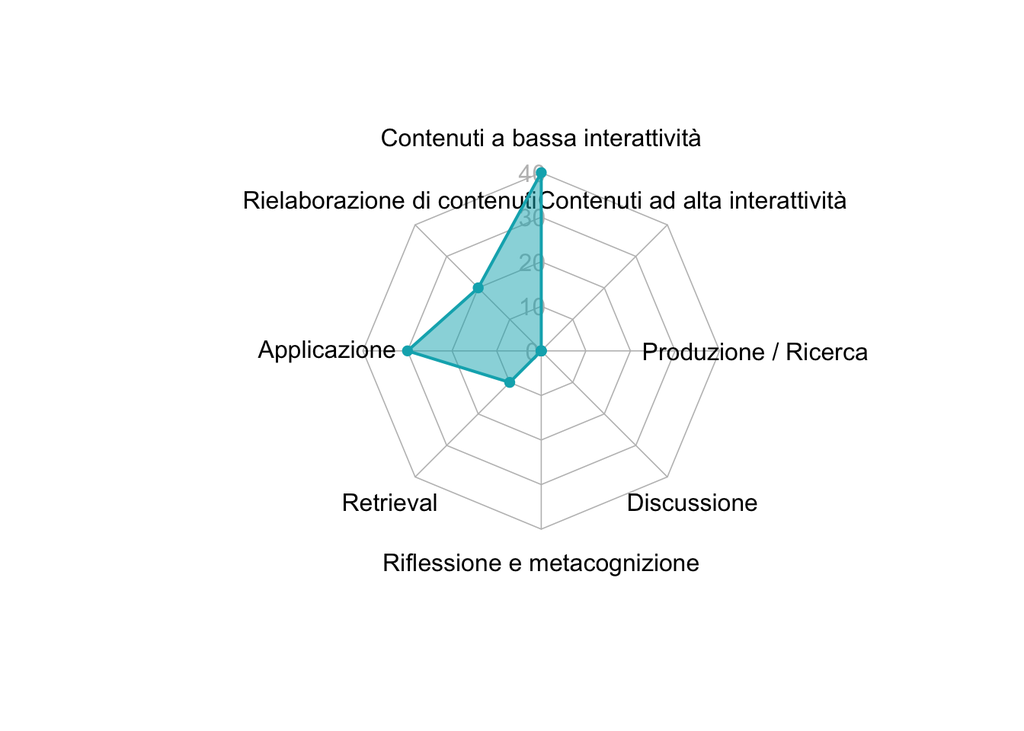

Contenuti a bassa interattività (40%): lezione frontale, lettura libro  
Rielaborazione di contenuti (20%): riassunti, schemi  
Applicazione (30%): esercizi  
Retrieval (10%): quiz

Si veda il metodo [Smart Learning Design 25](https://www.metid.polimi.it/en/) per ulteriori dettagli.

## Riconoscimenti

Vorrei ringraziare i Professori Andrea Pastore e Stefano Tonnellato per aver fornito tutto il materiale del corso e la struttura del corso. Eventuali errori o refusi sono esclusivamente mia responsabilità.